# Newsletter experiment results

Dani Cosme

2021-05-17

# load packages

```r
library(tidyverse)
library(knitr)
library(DT)
```

# load and tidy data

```r
data = read.csv("data/newsletter_data.csv", stringsAsFactors = FALSE) %>%
  mutate_if(is.numeric, ~ ifelse(is.na(.), 999, .)) %>%
  mutate(voting_link = ifelse(request_ballot == 1 | print_form == 1 | request_envelope == 1 | calendar == 1, 1, 0),
         info_involvement_link = ifelse(mailing_list == 1 | pennvotes == 1 | motivote == 1, 1, 0),
         opened_email = ifelse(!opened == 0, 1, 0)) %>%
  mutate_if(is.numeric, ~ ifelse(. == 999, NA, .)) %>%
  gather(var, val, contains("link"), opened_email) %>%
  group_by(group, var) %>%
  mutate(n = n(),
         sum = sum(val, na.rm = TRUE),
         percent = (sum / n) * 100) %>%
  ungroup()

data_sum = read.csv("data/newsletter_data.csv", stringsAsFactors = FALSE) %>%
  mutate_if(is.numeric, ~ ifelse(is.na(.), 999, .)) %>%
  mutate(voting_link = ifelse(request_ballot + print_form + request_envelope + calendar == 1, 1, 0),
         info_involvement_link = ifelse(mailing_list + pennvotes + motivote == 1, 1, 0),
         opened_email = ifelse(!opened == 0, 1, 0)) %>%
  mutate_if(is.numeric, ~ ifelse(. == 999, NA, .)) %>%
  gather(var, val, contains("link"), opened_email) %>%
  group_by(group, var) %>%
  mutate(n = n(),
         sum = sum(val, na.rm = TRUE),
         percent = (sum / n) * 100) %>%
  ungroup()
```

# groupings

`opened_email` = Opened the email

`voting_links` = Clicked on one or more links related to voting behavior

- Request a ballot
- Print request form
- Request envelope
- Check calendar

`info_involvement_links` = Clicked on one or more links to get more information

- Pennvotes.org
- Join the PLTV mailing list
- Join motivote

# summarize the data

Descriptives for each group and action category.

`total n` = total number of people in the group

`action n` = number of people who did this action (e.g. clicking on at least one link in the group)

`action percent` = percent of people who did this action (e.g. clicking on at least one link in the group)

```r
data %>%
  select(group, var, n, sum, percent) %>%
  unique() %>%
  mutate(percent = round(percent, 1)) %>%
  rename("action category" = var,
         "total n" = n,
         "action n" = sum,
         "action percent" = percent) %>%
  arrange(`action category`) %>%
  DT::datatable(rownames = FALSE, filter = 'top', extensions = 'FixedColumns',
                options = list(scrollX = TRUE,
                               scrollY = TRUE,
                               fixedColumns = list(leftColumns = 1)))
```

| group | action category | total n | action n | action percent |
| --- | --- | --- | --- | --- |
| control | info_involvement_link | 1477 | 2 | 0.1 |
| experimental | info_involvement_link | 1477 | 1 | 0.1 |
| control | opened_email | 1477 | 623 | 42.2 |
| experimental | opened_email | 1477 | 625 | 42.3 |
| control | voting_link | 1477 | 16 | 1.1 |
| experimental | voting_link | 1477 | 19 | 1.3 |

# visualize

## count

Number of people in each group who opened the email or clicked on at least one link in the category.

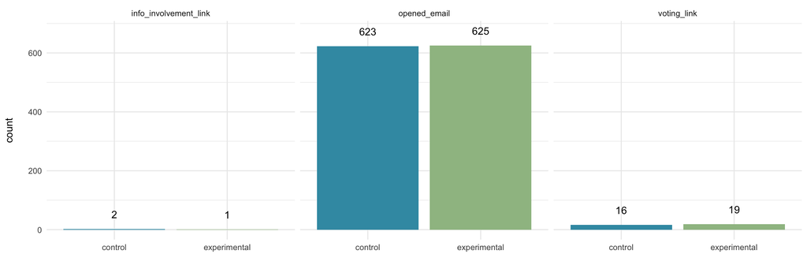

```r
data %>%
  filter(!val == 0) %>%
  ggplot(aes(group, fill = group)) +
  geom_bar(position = position_dodge(.9)) +
  geom_text(aes(label = stat(count)), stat = "count", nudge_y = 50) +
  facet_grid(~var) +
  scale_fill_manual(values = wesanderson::wes_palette("Zissou1", 4, "continuous")) +
  labs(x = "", y = "count\n") +
  theme_minimal() +
  theme(legend.position = "none")
```

## percent

Percentage of people in each group who opened the email or clicked on at least one link in the category.

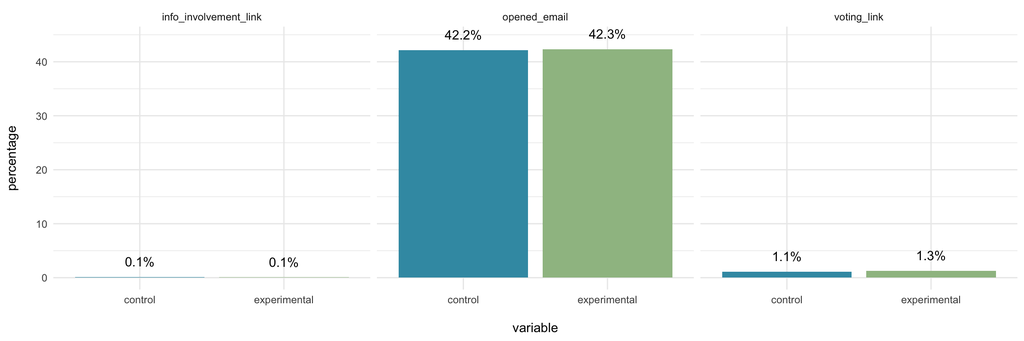

```r
data %>%
  select(group, var, percent) %>%
  unique() %>%
  ggplot(aes(group, percent, fill = group)) +
  geom_bar(stat = "identity", position = position_dodge(.9)) +
  geom_text(aes(label = sprintf("%.1f%%", percent)), vjust = 0, nudge_y = 2) +
  facet_grid(~var) +
  scale_fill_manual(values = wesanderson::wes_palette("Zissou1", 4, "continuous")) +
  labs(x = "\nvariable", y = "percentage\n") +
  theme_minimal() +
  theme(legend.position = "none")
```

## percentage of total clicks

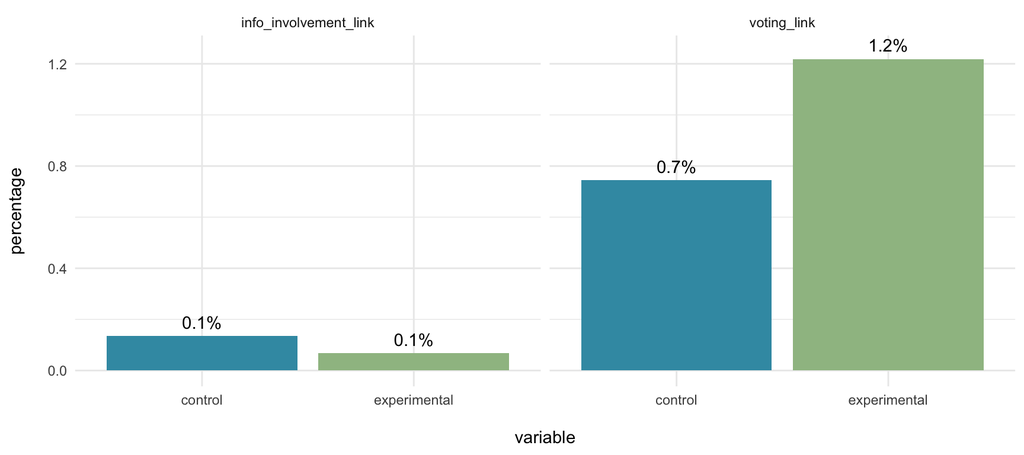

```r
data_sum %>%
  select(group, var, percent) %>%
  unique() %>%
  filter(!grepl("open", var)) %>%
  ggplot(aes(group, percent, fill = group)) +
  geom_bar(stat = "identity", position = position_dodge(.9)) +
  geom_text(aes(label = sprintf("%.1f%%", percent)), vjust = 0, nudge_y = .03) +
  facet_grid(~var) +
  scale_fill_manual(values = wesanderson::wes_palette("Zissou1", 4, "continuous")) +
  labs(x = "\nvariable", y = "percentage\n") +
  theme_minimal() +
  theme(legend.position = "none")
```

# stats

For all of these models, the differences between the control messages and the experimental messages are not statistically significant, meaning that any observed differences are likely due to chance.

```r
fit_mod = function(df) {
  m = glm(val ~ 1 + group, data = df, family = binomial(link = "logit"))
  m_plot = glm(val ~ 0 + group, data = df, family = binomial(link = "logit"))
  plot = sjPlot::plot_model(m_plot, transform = "plogis")
  return(list(m = m, plot = plot))
}

output = data %>%
  mutate(group = factor(group, levels = c("control", "experimental"))) %>%
  group_by(var) %>%
  nest() %>%
  mutate(model = map(data, fit_mod)) %>%
  select(-data) %>%
  unnest() %>%
  bind_cols(type = rep(c("model", "plot"), 3)) %>%
  spread(type, model) %>%
  mutate(tidy_mod = map(model, broom::tidy, conf.int = TRUE)) %>%
  select(-model) %>%
  unnest(tidy_mod) %>%
  mutate(term = gsub("group", "", term),
         term = gsub("\\(Intercept\\)", "Control \\(intercept\\)", term))
```

## opened email

### model

```r
var = "opened_email"
output %>%
  ungroup() %>%
  filter(var == !!var) %>%
  mutate(`logit [95% CI]` = sprintf("%.2f [%.2f, %.2f]", estimate, conf.low, conf.high)) %>%
  select(term, `logit [95% CI]`, p.value) %>%
  kable(digits = 2, format = "pandoc")
```

| term | logit [95% CI] | p.value |
| --- | --- | --- |
| Control (intercept) | -0.32 [-0.42, -0.21] | 0.00 |
| experimental | 0.01 [-0.14, 0.15] | 0.94 |

### plot

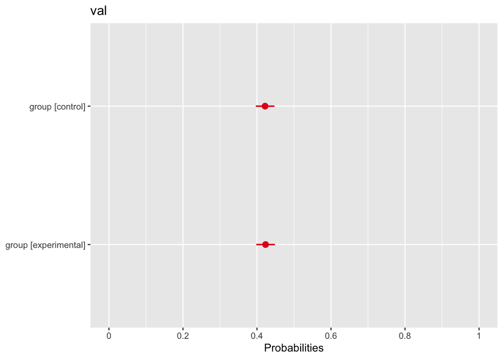

```r
filter(output, var == !!var)$plot[1]
```

## voting links

### model

```r
var = "voting_link"
output %>%
  ungroup() %>%
  filter(var == !!var) %>%
  mutate(`logit [95% CI]` = sprintf("%.2f [%.2f, %.2f]", estimate, conf.low, conf.high)) %>%
  select(term, `logit [95% CI]`, p.value) %>%
  kable(digits = 2, format = "pandoc")
```

| term | logit [95% CI] | p.value |
| --- | --- | --- |
| Control (intercept) | -4.51 [-5.05, -4.06] | 0.00 |
| experimental | 0.17 [-0.49, 0.86] | 0.61 |

### plot

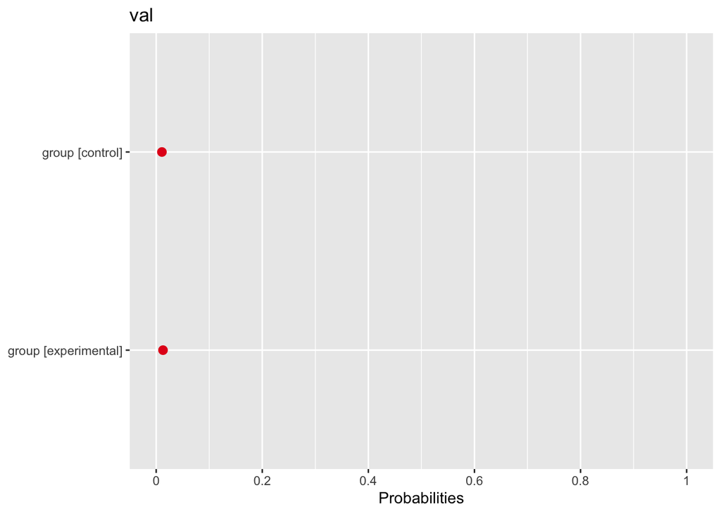

```r
filter(output, var == !!var)$plot[1]
```

## info & involvement links

### model

```r
var = "info_involvement_link"
output %>%
  ungroup() %>%
  filter(var == !!var) %>%
  mutate(`logit [95% CI]` = sprintf("%.2f [%.2f, %.2f]", estimate, conf.low, conf.high)) %>%
  select(term, `logit [95% CI]`, p.value) %>%
  kable(digits = 2, format = "pandoc")
```

| term | logit [95% CI] | p.value |
| --- | --- | --- |
| Control (intercept) | -6.60 [-8.40, -5.47] | 0.00 |
| experimental | -0.69 [-3.76, 1.65] | 0.57 |

### plot

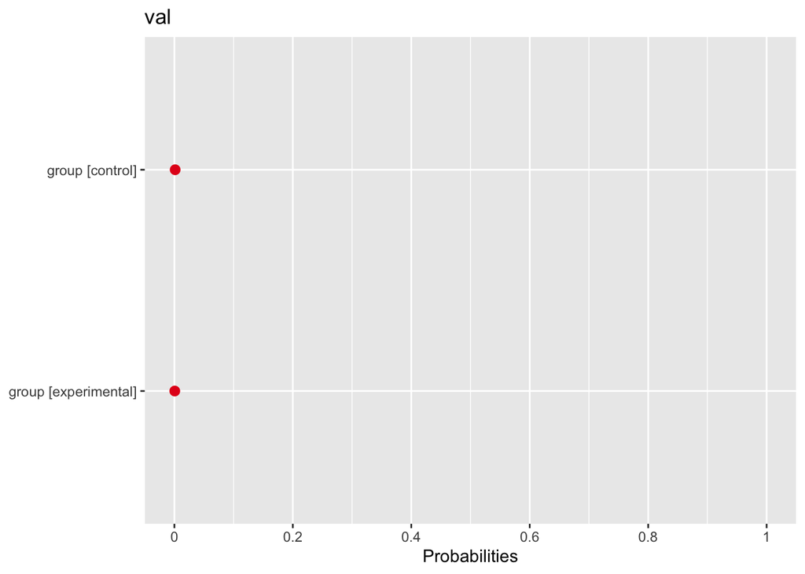

```r
filter(output, var == !!var)$plot[1]
```